| Conteúdo | Intervalo de Confiança, Margem de Erro, Acurácia e Precisão >

# O Teorema Central do Limite

Primeiramente, vamos passar por alguns conceitos.

Suponha que há uma **população** (*population*) de interesse e que foi coletada uma **amostra aleatória** (*random sample*) da mesma. Suponha também que a partir desta amostra (*sample*) foi calculada alguma **estatística desta amostra** (*sample statistic*), por exemplo, a média (*mean*) desta amostra (*sample*).

Suponha que uma outra **amostra aleatória** (*random sample*) seja coletada e que a sua média (*mean*) seja também calculada e armazenada, e que este mesmo processo se repita muitas vezes.

Cada uma destas **amostras aleatórias** (*random samples*) terá a sua própria distribuição, que é denominada **distribuição da amostra** (*sample distribution*). Cada observação pertencente a uma destas distribuições é uma **unidade amostrada aleatoriamente** (*randomly sampled unit*) da **população** (*population*); digamos, uma pessoa, um gato ou um cachorro dependendo de qual é a **população** (*population*) a ser estudada.

Além disto, os valores que foram calculados e armazenados, as **estatísticas das amostras** (*sample statistics*), também formam uma nova distribuição. No entanto, nesta nova distribuição, cada observação da mesma não é mais uma unidade da **população** (*population*), mas sim uma **estatística desta amostra** (*sample statistic*), no nosso exemplo, a média da amostra (*sample mean*). A distribuição destas **estatísticas das amostras** (*sample statistics*) é denominada **distribuição amostral** (*sampling distribution*).

Logo, os dois termos **distribuição da amostra** (*sample distribution*) e **distribuição amostral** (*sampling distribution*) parecem similares, porém, representam conceitos diferentes.

[figure not shown]

(Inspiração: [Inferential Statistics](https://www.coursera.org/learn/inferential-statistics-intro/home/welcome), by Duke University, at Coursera)

Geralmente, não temos acesso à **população** (*population*) e, portanto, nem aos seus parâmetros (por exemplo, a média da população $\mu$). Na prática, temos acesso a **amostras aleatórias** (*random samples*) desta **população** (*population*).

Então, para estimar o valor de um parâmetro da **população** (*population*) utilizamos uma **estatística da amostra** (*sample statistic*) como se fosse uma **estimativa pontual** (*point estimate*) para o parâmetro da **população** (*population*). Como exemplo, a média da amostra (*sample mean*) é utilizada para estimar a média da população (*population mean*).

No entanto, estas **estimativas pontuais** (*point estimates*) irão variar de uma **amostra aleatória** (*random sample*) para outra. Esta variabilidade é a **variabilidade amostral** (*sampling variability*), também conhecida como **erro padrão** (*standard error*) $SE$.

Então, o **Teorema Central do Limite** (*Central Limit Theorem - CLT*) estabelece que quando o tamanho das amostras (*samples*) é suficientemente grande, a distribuição das **estatísticas das amostras** (*sample statistics*) é **aproximadamente normal** (*nearly normal*) sendo que quando a **estatística da amostra** (*sample statistic*) é a média, então, esta distribuição é centrada na média da população (*population mean*) e com um desvio padrão (*standard deviation*) igual ao desvio padrão da população (*population standard deviation*) dividido pela raiz quadrada do tamanho das amostras (*samples size*).

$$ \bar{X} \sim N\left(mean=\mu, SE=\frac{\sigma}{\sqrt{n}}\right) $$

As condições para que o **Teorema Central do Limite** (*Central Limit Theorem - CLT*) seja válido são:

- **Independência** (*Independence*): as unidades amostradas aleatoriamente (*randomly sampled units*) devem ser independentes, ou seja, a ocorrência de uma dada unidade amostrada (*sampled unit*) da população (*population*) não afeta a probabilidade da ocorrência de outra.
- **Tamanho da Amostra/Amostra Enviesada** (*Sample Size/Skewed*): ou a distribuição da população (*population*) é normal, ou se a distribuição da população (*population*) é enviesada (*skewed*), o tamanho da amostra (*sample size*) tem que ser grande (regra de ouro: $n > 30$).

Repare que, respeitadas as condições, o **Teorema Central do Limite** (*Central Limit Theorem - CLT*) aplica-se independentemente da forma da distribuição da população (*population*), ou seja, mesmo que a população (*population*) não tenha uma distribuição normal, a **distribuição amostral** (*sampling distribution*) das **estatísticas das amostras** (*sample statistics*) será **aproximadamente normal** (*nearly normal*).

Muitos procedimentos estatísticos comuns requerem que os dados sejam aproximadamente normais, daí a importância do **Teorema Central do Limite** (*Central Limit Theorem - CLT*).

Então, vamos verificar na prática a realização do **Teorema Central do Limite** (*Central Limit Theorem - CLT*) através de algumas simulações simples.

Primeiramente, vamos importar alguns pacotes.

```python
from scipy import stats as st
import pandas as pd
import numpy as np

# Import some dependencies to visualization with altair
import altair as alt
alt.renderers.enable('notebook') # for the notebook only (not for JupyterLab) run this command once per session
```

```
RendererRegistry.enable('notebook')
```

Na nossa simulação, vamos testar como o **Teorema Central do Limite** (*Central Limit Theorem - CLT*) se comporta para $3$ tamanhos diferentes de amostras (*samples*), no caso: $10$, $30$ e $500$. Além disto, vamos coletar $5.000$ amostras (*samples*) da população (*population*) de interesse, ou seja, o tamanho da **distribuição amostral** (*sampling distribution*) das **estatísticas das amostras** (*sample statistics*) será igual a $5.000$.

```python
random_sample_size1 = 10
random_sample_size2 = 30
random_sample_size3 = 500

sampling_distribution_size = 5000
```

Então, a nossa simulação consiste em:

1. Escolher uma distribuição para representar a **população** (*population*) de interesse.
2. Coletar, aleatoriamente, $n$ valores a partir desta **distribuição** (*distribution*) e calcular a **média** (*mean*) destes valores (aqui, já sabemos que experimentaremos com $3$ valores diferentes de $n$: $10$, $30$ e $500$).
3. Repetir os passos anteriores $m$ vezes obtendo $m$ **médias** (*means*). Aqui, já sabemos que $m = 5.000$ (`sampling_distribution_size`).
4. Finalmente:
   1. Plotar a curva que representa a **distribuição** (*distribution*) teórica selecionada no passo $1$.
   2. Plotar o histograma das $m$ **médias** (*means*), ou seja, plotar a **distribuição amostral** (*sampling distribution*) das **estatísticas das amostras** (*sample statistics*).
   3. Verificar se o **histograma da distribuição amostral** (*histogram of the sampling distribution*) tem um formato que se aproxima de uma distribuição normal independentemente da **distribuição** (*distribution*) teórica selecionada no passo $1$.
   4. Verificar se a média da **distribuição amostral** (*sampling distribution*) é uma boa aproximação para a média da **distribuição da população** (*population distribution*).
   5. Verificar se o desvio padrão (*standard deviation*) da **distribuição amostral** (*sampling distribution*) é uma boa aproximação para $\frac{\sigma}{\sqrt{n}}$.

As funções abaixo são funções utilitárias para plotar os gráficos e nos ajudar a verificar os itens A, B e C.

```python
def draw_hist_plot(sampling_distribution, sampling_distribution_size, random_sample_size, x_axis_limits=None):
    sampling_distribution_mean = np.mean(sampling_distribution)
    sampling_distribution_sd = np.std(sampling_distribution)
    title = 'Sampling Dist. (m={0}, n={1}) of Means | mean={2:.2f} se={3:.2f}'.format(
        sampling_distribution_size, random_sample_size, sampling_distribution_mean, sampling_distribution_sd
    )

    data = pd.DataFrame({'means': sampling_distribution})
    hist = None
    if x_axis_limits is None:
        hist = alt.Chart(data).mark_bar().encode(
            alt.X('means', bin=True),
            alt.Y('count()')
        ).properties(title=title)
    else:
        hist = alt.Chart(data).mark_bar().encode(
            alt.X('means', bin=True, scale=alt.Scale(domain=x_axis_limits)),
            alt.Y('count()')
        ).properties(title=title)

    rule = alt.Chart(data).mark_rule(color='red').encode(
        x='mean(means)',
        size=alt.value(2)
    )
    return hist + rule

def draw_density_plot(pop_distribution, distribution_name):
    # Create the points to draw the probability density function
    x_i = pop_distribution.ppf(0.001)
    x_f = pop_distribution.ppf(0.999)
    x = np.linspace(x_i, x_f, 100)
    f_x = pop_distribution.pdf(x)

    # draw the density function f(x)
    data = pd.DataFrame({'x': x, 'f(x)': f_x})
    density = alt.Chart(data).mark_line().encode(
        x='x',
        y='f(x)'
    ).properties(title='Population = {0}'.format(distribution_name))
    return density

def draw_plots(pop_distribution, distribution_name, sampling_distribution1, sampling_distribution2, sampling_distribution3):
    density_plot = draw_density_plot(pop_distribution, distribution_name)

    x_axis_limits = (np.min(sampling_distribution1), np.max(sampling_distribution1))
    hist1_plot = draw_hist_plot(sampling_distribution1, sampling_distribution_size, random_sample_size1)
    hist2_plot = draw_hist_plot(sampling_distribution2, sampling_distribution_size, random_sample_size2, x_axis_limits)
    hist3_plot = draw_hist_plot(sampling_distribution3, sampling_distribution_size, random_sample_size3, x_axis_limits)

    row1_plot = density_plot | hist1_plot
    row2_plot = (hist2_plot | hist3_plot).resolve_scale(x='shared')
    return alt.vconcat(row1_plot, row2_plot)
```

A função abaixo é uma função utilitária para nos ajudar a verificar os itens D e E.

```python
def print_pop_stdv_and_bestguess_stdv(pop_distribution, sampling_distribution1, sampling_distribution2,
                                      sampling_distribution3):
    pop_standard_deviation = np.sqrt(pop_distribution.stats(moments='v'))

    standard_error_sampling_dist1 = np.std(sampling_distribution1)
    standard_error_sampling_dist2 = np.std(sampling_distribution2)
    standard_error_sampling_dist3 = np.std(sampling_distribution3)

    best_guess1_pop_stdv = standard_error_sampling_dist1*np.sqrt(random_sample_size1)
    best_guess2_pop_stdv = standard_error_sampling_dist2*np.sqrt(random_sample_size2)
    best_guess3_pop_stdv = standard_error_sampling_dist3*np.sqrt(random_sample_size3)

    print("Population standard deviation (pop_stdv) = {0} ~ {1:.1f}".format(
        pop_standard_deviation, pop_standard_deviation
    ))
    print("Best guess for pop_stdv from a sampling distribution (m={0}, n={1}) = {2} ~ {3:.1f}".format(
        sampling_distribution_size, random_sample_size1, best_guess1_pop_stdv, best_guess1_pop_stdv
    ))
    print("Best guess for pop_stdv from a sampling distribution (m={0}, n={1}) = {2} ~ {3:.1f}".format(
        sampling_distribution_size, random_sample_size2, best_guess2_pop_stdv, best_guess2_pop_stdv
    ))
    print("Best guess for pop_stdv from a sampling distribution (m={0}, n={1}) = {2} ~ {3:.1f}\n".format(
        sampling_distribution_size, random_sample_size3, best_guess3_pop_stdv, best_guess3_pop_stdv
    ))
```

Finalmente, a função abaixo é a função que irá executar as replicações da simulação para criar uma **distribuição amostral** (*sampling distribution*) para cada um dos $3$ tamanhos diferentes de amostras (*samples*) que iremos simular.

```python
def make_sampling_distributions(pop_distribution):
    sampling_distribution_of_means1 = []
    sampling_distribution_of_means2 = []
    sampling_distribution_of_means3 = []
    for _ in range(sampling_distribution_size):
        random_sample = pop_distribution.rvs(size=random_sample_size1)
        sample_statistic = random_sample.mean()
        sampling_distribution_of_means1.append(sample_statistic)

        random_sample = pop_distribution.rvs(size=random_sample_size2)
        sample_statistic = random_sample.mean()
        sampling_distribution_of_means2.append(sample_statistic)

        random_sample = pop_distribution.rvs(size=random_sample_size3)
        sample_statistic = random_sample.mean()
        sampling_distribution_of_means3.append(sample_statistic)

    return sampling_distribution_of_means1, sampling_distribution_of_means2, sampling_distribution_of_means3
```

As seções subsequentes realizam o mesmo experimento para diferentes **distribuições** (*distributions*) teóricas.

## Experimento que considera uma população com distribuição Normal

https://en.wikipedia.org/wiki/Normal_distribution

```python
%%time

# Definition of the population distribution
pop_par_mu = 0
pop_par_sd = 1
pop_distribution = st.norm(loc=pop_par_mu, scale=pop_par_sd)
pop_distribution_name = "Normal(mean={0},sd={1})".format(pop_par_mu,pop_par_sd)

# Making the sampling distributions of the means
sampling_dist_of_means1, sampling_dist_of_means2, sampling_dist_of_means3 = make_sampling_distributions(pop_distribution)

# Check if the standard error of the sampling distribution approximates from stdv(pop)/sqrt(n)
print_pop_stdv_and_bestguess_stdv(
    pop_distribution, sampling_dist_of_means1, sampling_dist_of_means2, sampling_dist_of_means3
)
```

```
Population standard deviation (pop_stdv) = 1.0 ~ 1.0
Best guess for pop_stdv from a sampling distribution (m=5000, n=10) = 0.9950919316179327 ~ 1.0
Best guess for pop_stdv from a sampling distribution (m=5000, n=30) = 0.9924488011490721 ~ 1.0
Best guess for pop_stdv from a sampling distribution (m=5000, n=500) = 1.0038939955529231 ~ 1.0

Wall time: 590 ms
```

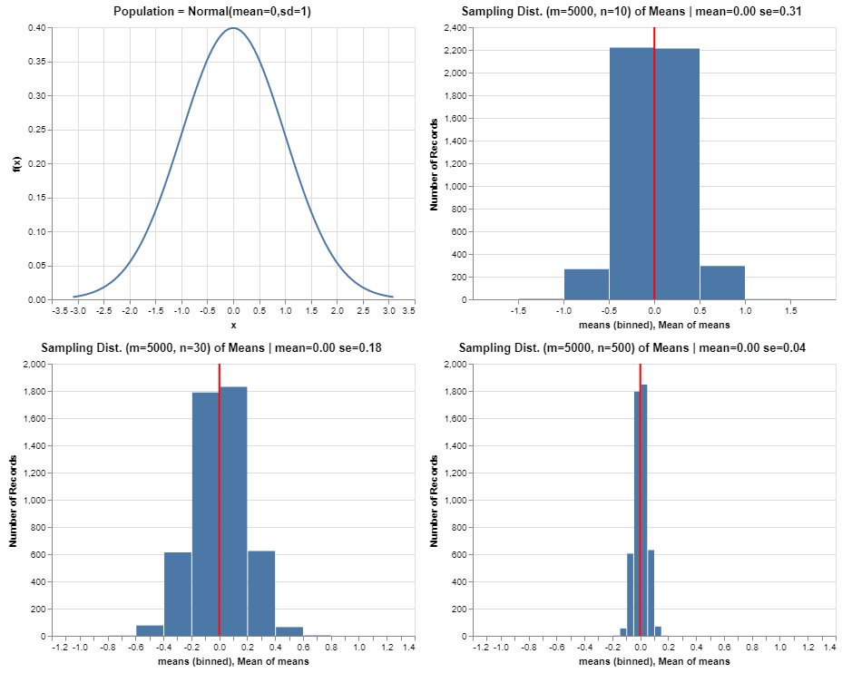

```python
# Draw plot of the density function that represents the population distribution
# and histogram of sampling distributions
draw_plots(
    pop_distribution, pop_distribution_name,
    sampling_dist_of_means1, sampling_dist_of_means2, sampling_dist_of_means3
)
```

## Experimento que considera uma população com distribuição Uniforme

https://en.wikipedia.org/wiki/Uniform_distribution_(continuous)

```python
%%time

# Definition of the population distribution
pop_par_a = 1
pop_par_b = 10
pop_distribution = st.uniform(loc=pop_par_a, scale=(pop_par_b-pop_par_a))
pop_mean, pop_var = pop_distribution.stats(moments='mv')
pop_distribution_name = "Uniform(a={0},b={1}) with mean={2}, std={3:.1f}".format(
    pop_par_a, pop_par_b, pop_mean, np.sqrt(pop_var)
)

# Making the sampling distributions of the means
sampling_dist_of_means1, sampling_dist_of_means2, sampling_dist_of_means3 = make_sampling_distributions(pop_distribution)

# Check if the standard error of the sampling distribution approximates from stdv(pop)/sqrt(n)
print_pop_stdv_and_bestguess_stdv(
    pop_distribution, sampling_dist_of_means1, sampling_dist_of_means2, sampling_dist_of_means3
)
```

```
Population standard deviation (pop_stdv) = 2.598076211353316 ~ 2.6
Best guess for pop_stdv from a sampling distribution (m=5000, n=10) = 2.592166388310561 ~ 2.6
Best guess for pop_stdv from a sampling distribution (m=5000, n=30) = 2.576038004791108 ~ 2.6
Best guess for pop_stdv from a sampling distribution (m=5000, n=500) = 2.5657694868143803 ~ 2.6

Wall time: 601 ms
```

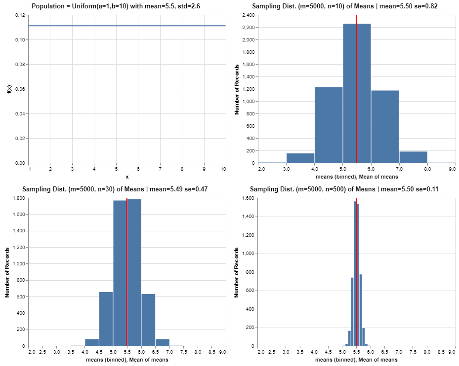

```python
# Draw plot of the density function that represents the population distribution
# and histogram of sampling distributions
draw_plots(
    pop_distribution, pop_distribution_name,
    sampling_dist_of_means1, sampling_dist_of_means2, sampling_dist_of_means3
)
```

## Experimento que considera uma população com distribuição Exponencial

https://en.wikipedia.org/wiki/Exponential_distribution

```python
%%time

# Definition of the population distribution
pop_par_lambda = 1.5
pop_distribution = st.expon(scale=(1 / pop_par_lambda))
pop_mean, pop_var = pop_distribution.stats(moments='mv')
pop_distribution_name = "Exponential(lambda={0}) with mean={1:.2f}, std={2:.1f}".format(
    pop_par_lambda, pop_mean, np.sqrt(pop_var)
)

# Making the sampling distributions of the means
sampling_dist_of_means1, sampling_dist_of_means2, sampling_dist_of_means3 = make_sampling_distributions(pop_distribution)

# Check if the standard error of the sampling distribution approximates from stdv(pop)/sqrt(n)
print_pop_stdv_and_bestguess_stdv(
    pop_distribution, sampling_dist_of_means1, sampling_dist_of_means2, sampling_dist_of_means3
)
```

```
Population standard deviation (pop_stdv) = 0.6666666666666666 ~ 0.7
Best guess for pop_stdv from a sampling distribution (m=5000, n=10) = 0.6736114597809856 ~ 0.7
Best guess for pop_stdv from a sampling distribution (m=5000, n=30) = 0.6711935066093957 ~ 0.7
Best guess for pop_stdv from a sampling distribution (m=5000, n=500) = 0.6715332761731232 ~ 0.7

Wall time: 613 ms
```

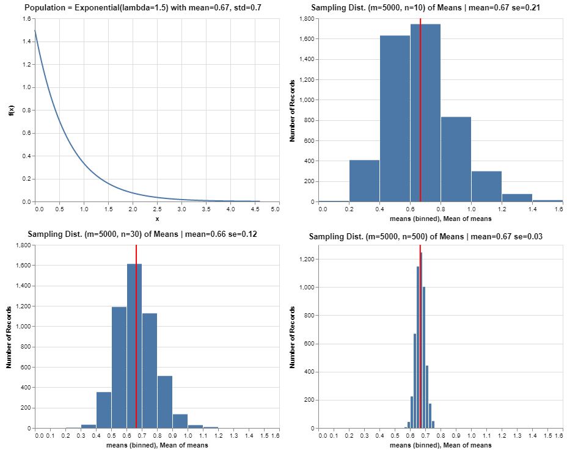

```python
# Draw plot of the density function that represents the population distribution
# and histogram of sampling distributions
draw_plots(
    pop_distribution, pop_distribution_name,
    sampling_dist_of_means1, sampling_dist_of_means2, sampling_dist_of_means3
)
```

## Experimento que considera uma população com distribuição Gama

https://en.wikipedia.org/wiki/Gamma_distribution

```python
%%time

# Definition of the population distribution
pop_par_shape = 2.0
pop_par_scale = 2.0
pop_distribution = st.gamma(a=pop_par_shape, scale=pop_par_scale)
pop_mean, pop_var = pop_distribution.stats(moments='mv')
pop_distribution_name = "Gamma(shape={0},scale={1}) with mean={2:.2f}, std={3:.1f}".format(
    pop_par_shape, pop_par_scale, pop_mean, np.sqrt(pop_var)
)

# Making the sampling distributions of the means
sampling_dist_of_means1, sampling_dist_of_means2, sampling_dist_of_means3 = make_sampling_distributions(pop_distribution)

# Check if the standard error of the sampling distribution approximates from stdv(pop)/sqrt(n)
print_pop_stdv_and_bestguess_stdv(
    pop_distribution, sampling_dist_of_means1, sampling_dist_of_means2, sampling_dist_of_means3
)
```

```
Population standard deviation (pop_stdv) = 2.8284271247461903 ~ 2.8
Best guess for pop_stdv from a sampling distribution (m=5000, n=10) = 2.841088654717637 ~ 2.8
Best guess for pop_stdv from a sampling distribution (m=5000, n=30) = 2.7939083491456165 ~ 2.8
Best guess for pop_stdv from a sampling distribution (m=5000, n=500) = 2.8218486148810724 ~ 2.8

Wall time: 767 ms
```

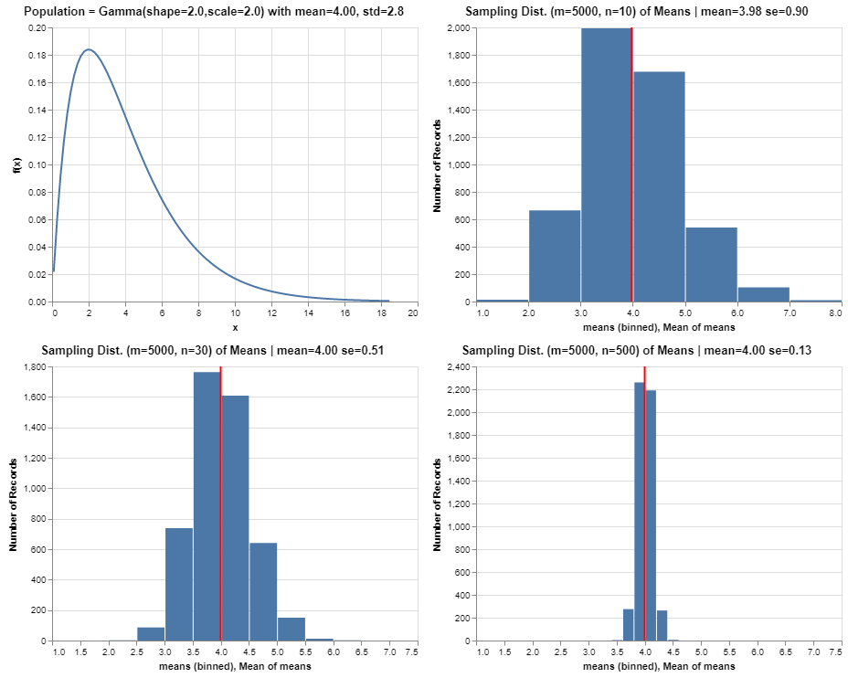

```python
# Draw plot of the density function that represents the population distribution
# and histogram of sampling distributions
draw_plots(
    pop_distribution, pop_distribution_name,
    sampling_dist_of_means1, sampling_dist_of_means2, sampling_dist_of_means3
)
```

https://en.wikipedia.org/wiki/Log-normal_distribution

```python
%%time

# Definition of the population distribution
pop_par_mu = np.exp(0)
pop_par_sd = 1.5 # example of heavy tail
pop_distribution = st.lognorm(s=pop_par_sd, loc=0, scale=pop_par_mu)
pop_distribution_name = "Log-Normal(mean={0},sd={1})".format(pop_par_mu, pop_par_sd)

# Making the sampling distributions of the means
sampling_dist_of_means1, sampling_dist_of_means2, sampling_dist_of_means3 = make_sampling_distributions(pop_distribution)

# Check if the standard error of the sampling distribution approximates from stdv(pop)/sqrt(n)
print_pop_stdv_and_bestguess_stdv(
    pop_distribution, sampling_dist_of_means1, sampling_dist_of_means2, sampling_dist_of_means3
)
```

```
Population standard deviation (pop_stdv) = 8.973817218116451 ~ 9.0
Best guess for pop_stdv from a sampling distribution (m=5000, n=10) = 12.84903296154455 ~ 12.8
Best guess for pop_stdv from a sampling distribution (m=5000, n=30) = 8.465172993797152 ~ 8.5
Best guess for pop_stdv from a sampling distribution (m=5000, n=500) = 8.96255619874519 ~ 9.0

Wall time: 740 ms
```

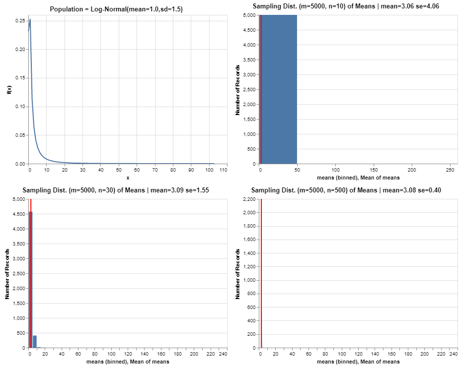

```python
# Draw plot of the density function that represents the population distribution
# and histogram of sampling distributions
draw_plots(
    pop_distribution, pop_distribution_name,
    sampling_dist_of_means1, sampling_dist_of_means2, sampling_dist_of_means3
)
```

Como pode ser visto na Wikipedia:

> *In more general usage, a central limit theorem is any of a set of weak-convergence theorems in probability theory. They all express the fact that a sum of many independent and identically distributed ($i.i.d.$) random variables, or alternatively, random variables with specific types of dependence, will tend to be distributed according to one of a small set of attractor distributions. **When the variance of the $i.i.d.$ variables is finite, the attractor distribution is the normal distribution**. In contrast, the sum of a number of $i.i.d.$ random variables with power law tail distributions decreasing as $|x|^{−\alpha −1}$ where $0 < \alpha < 2$ **(and therefore having infinite variance) will tend to an alpha-stable distribution** with stability parameter (or index of stability) of $\alpha$ as the number of variables grows.* (Fonte: https://en.wikipedia.org/wiki/Central_limit_theorem)

## Resumo

**R1.** Uma estatística da amostra (*sample statistic*) é uma estimativa pontual (*point estimate*) para um parâmetro da população (*population*), por exemplo, a média da amostra (*sample mean*) é utilizada para estimar a média da população (*population mean*). Os termos estatística da amostra (*sample statistic*) e estimativa pontual (*point estimate*) são sinônimos.

**R2.** Estimativas pontuais (*point estimates*) variam de uma amostra (*sample*) para outra. Esta variabilidade é a variabilidade amostral (*sampling variability*), também conhecida como erro padrão (*standard error*) $SE$.

**R3.** A variabilidade amostral (*sampling variability*) da **média**, ou seja o erro padrão (*standard error*) $SE$ da **média**, é calculada como $SE=\frac{\sigma}{\sqrt{n}}$, onde $\sigma$ é o desvio padrão (*standard deviation*) da população (*population*).

- Quando o desvio padrão (*standard deviation*) $\sigma$ da população (*population*) não é conhecido (quase sempre), então, o erro padrão (*standard error*) $SE$ pode ser estimado através do desvio padrão (*standard deviation*) da amostra (*sample*) $s$, de forma que $SE \approx \hat{se}=\frac{s}{\sqrt{n}}$.

**R4.** O Teorema Central do Limite (*Central Limit Theorem - CLT*) diz respeito à distribuição das estatísticas das amostras (*sample statistics*) e, sob certas condições, esta distribuição será aproximadamente normal (*nearly normal*).

Quando a estatística da amostra (*sample statistic*) é a **média**, então, o Teorema Central do Limite (*Central Limit Theorem - CLT*) estabelece que se:

- (1a) o tamanho da amostra (*sample size*) é suficientemente grande ($n > 30$ ou maior se os dados são consideravelmente enviesados), ou
- (1b) sabe-se de antemão que a população (*population*) tem uma distribuição normal, e
- (2) as observações da amostra (*sample*) são independentes,

então a distribuição das médias das amostras (*samples*) será aproximadamente normal (*nearly normal*), centrada na média da população (*population mean*) $\mu$ e com um erro padrão (*standard error*) de $SE=\frac{\sigma}{\sqrt{n}}$:

$$ \bar{X} \sim N\left(mean=\mu, SE=\frac{\sigma}{\sqrt{n}}\right) $$

*Referências:*

- https://en.wikipedia.org/wiki/Point_estimation
- https://www.youtube.com/watch?v=YAlJCEDH2uY&t=129s
- https://en.wikipedia.org/wiki/Central_limit_theorem

| Conteúdo | Intervalo de Confiança, Margem de Erro, Acurácia e Precisão >